# Week 6 weekend homework

# 1.1 Hypothesis testing - practical

```r
library(tidyverse)
library(infer)

data(msleep)
```

**Question 2**

Jabberwockies sleep for around 7 hours a night, on average. Perform an appropriate statistical test to determine whether the mean sleep_total in the sampled population of animal types differs from the typical value for jabberwockies.

**Answer 2**

In this experiment we are comparing the mean of a sampled variable with a null value, we will therefore perform a one-mean test.

Our null hypothesis is that Jabberwockies sleep on average the same amount of time as the animals in our dataset.

Our alternative hyposthesis is that, on average, Jabberwockies do not sleep the same amount of time as the animals in our dataset.

Step 1: We set a significance level of 5% for our test.

Step 2: Calculate mean(sleep_total) from msleep dataset (this is the observed statistic from our sample data)

```r
sleep_total_mean <- msleep %>%
  summarise(avg_sleep = mean(sleep_total))
```

We find that the average sleep for all animals in the dataset is 10.43.

Step 3: We generate a null distribution. Inputting mu = 7 as we know that this is the average sleep total for jabberwockies. As we are performing a one mean test, we use a bootstrap sample with our stat = “mean”.

```r
(q2_null_sample_distribution <- msleep %>%
  specify(response = sleep_total) %>%
  hypothesise(null = "point", mu = 7) %>%
  generate(reps = 10000, type = "bootstrap") %>%
  calculate(stat = "mean"))
```

```
Response: sleep_total (numeric)
Null Hypothesis: point
```

| replicate | stat |
| --- | --- |
| 1 | 7.303614 |
| 2 | 5.879518 |
| 3 | 7.179518 |
| 4 | 6.715663 |
| 5 | 7.777108 |
| 6 | 6.225301 |
| 7 | 6.912048 |
| 8 | 6.938554 |
| 9 | 7.230120 |
| 10 | 6.740964 |

[output cut: 990 more lines]

Step 4: we visualise and calculate our p-value. As our alternative hyposthesis is that on average, Jabberwockies do not sleep the same amount of time as the animals in our dataset we can use direction = “both”, i.e. we are not suggesting that jabberwockies sleep more or less than the animals in our dataset, simply that the sleep time is not the same.

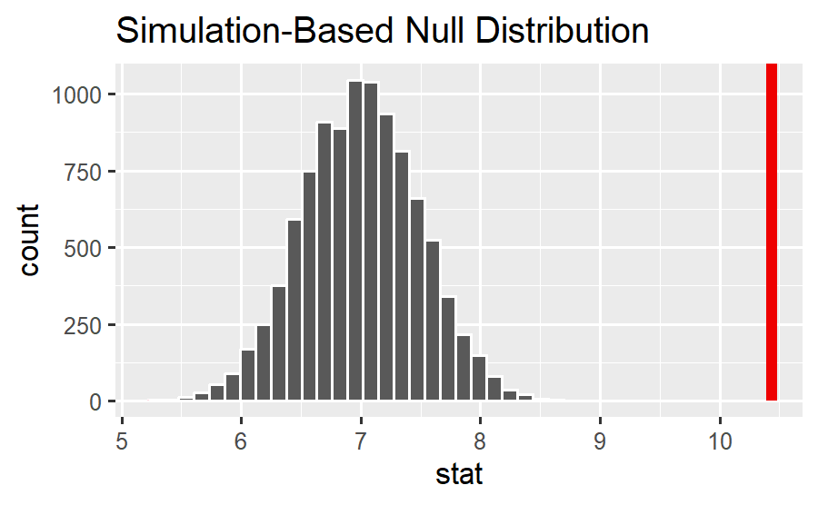

```r
(q2_null_sample_distribution %>%
  visualise(bins = 30) +
  shade_pvalue(obs_stat = sleep_total_mean$avg_sleep,
               direction = "both"))
```

```r
(q2_null_sample_distribution %>%
  get_pvalue(obs_stat = sleep_total_mean$avg_sleep,
               direction = "both"))
```

| p_value |
| --- |
| 0 |

Step 5: conclusion

Our p-value for this hypothesis test is < 0.001. As this is less than our chosen confidence level of 5%, we can reject our null hypothesis in favour of our alternative hypothesis, i.e. we can say with confidence that Jabberwockies do not sleep the same amount of time as the animals in our dataset.

**Question 3** Perform an appropriate statistical test to determine whether omnivores sleep for significantly longer than herbivores, on average.

**Answer 3**

Our null hypothesis is that, on average, omnivores do not sleep significantly longer than herbivores.

Our alternative hypothesis is that, on average, omnivores sleep significantly longer than herbivores

Step 1: We set a significance level of 5% for our test.

Step 2: We calculate the observed statistic using the omnivore and herbivore data from our dataset.

```r
# msleep %>%
#  distinct(vore)

(omni_herbi_sleep <- msleep %>%
   filter(vore %in% c("omni", "herbi")) %>%
   select(vore, sleep_total)
)
```

| vore | sleep_total |
| --- | --- |
| omni | 17.0 |
| herbi | 14.4 |
| omni | 14.9 |
| herbi | 4.0 |
| herbi | 14.4 |
| herbi | 3.0 |
| herbi | 5.3 |
| herbi | 9.4 |
| omni | 10.0 |
| herbi | 12.5 |

[output cut: 42 more lines]

```r
(q3_observed_stat <- omni_herbi_sleep %>%
    specify(sleep_total ~ vore) %>%
    calculate(stat = "diff in means",
              order = c("omni", "herbi"))
)
```

```
Response: sleep_total (numeric)
Explanatory: vore (factor)
```

| stat |
| --- |
| 1.415625 |

In this experiment, we are comparing two independent means. We therefore use the relevant hypothesis tests for two independent samples. For this, we use permute and our observed stat is the difference between the two mean sleep times for omnivores and herbivores.

Step 3: We calculate our null sampling distribution

```r
(q3_null_sample_distribution <-  omni_herbi_sleep %>%
  specify(sleep_total ~ vore) %>%
  hypothesize(null = "independence") %>%
  generate(reps = 1000, type = "permute") %>%
  calculate(stat = "diff in means", c("omni", "herbi"))
)
```

```
Response: sleep_total (numeric)
Explanatory: vore (factor)
Null Hypothesis: independence
```

| replicate | stat |
| --- | --- |
| 1 | -0.721250 |
| 2 | -0.542500 |
| 3 | -0.420625 |
| 4 | -0.136250 |
| 5 | 0.855000 |
| 6 | -0.745625 |
| 7 | -0.575000 |
| 8 | -0.436875 |
| 9 | 0.156250 |
| 10 | 0.635625 |

[output cut: 990 more lines]

Step 4: We visualise our null sampling distribution and calculate our p-value

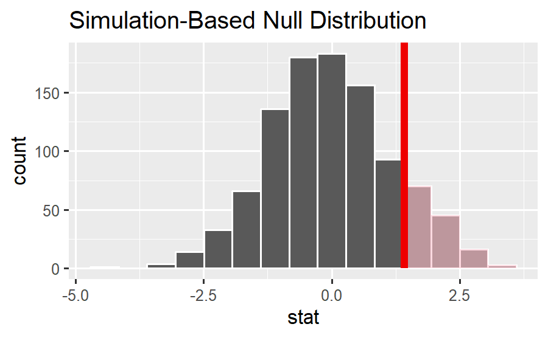

```r
(q3_null_sample_distribution %>%
  visualise() +
  shade_p_value(obs_stat = q3_observed_stat,
                direction = "greater")
)
```

```r
q3_null_sample_distribution %>%
  get_pvalue(obs_stat = q3_observed_stat,
                direction = "greater")
```

| p_value |
| --- |
| 0.126 |

```r
NA
```

Step 5: conclusion

Our p-value for this hypothesis test is 13% . As this is greater than our chosen confidence level of 5%, we cannot reject our null hypothesis in favour of our alternative hypothesis, i.e. we can say with confidence that, on average, omnivores do not sleep significantly longer than herbivores.

**Question 4.**

Perform an appropriate statistical test to determine whether the proportion of domesticated animal types in the population of animal types is greater than 5%.

**Answer 4.**

Our null hypothesis is that the proportion of domesticated animal types in the populations of animal types is less than or equal to 5%.

Our alternative hypothesis is that the proportion of domesticated animal types in the population of animal types is greater than 5%.

Step 1: We set a significance level of 5% for our test.

Step 2: We update our dataset appropriately and calculate the proportion of animals in the dataset that are domesticated. We also calculate our observed statistic for this hypothesis test.

```r
msleep_with_domesticated_info <- msleep %>%
  mutate(is_domesticated = if_else(
    is.na(conservation) | conservation != "domesticated",
                                   FALSE,
                                   TRUE))

(q4_observed_stat <- msleep_with_domesticated_info %>%
  specify(response = is_domesticated,
          success = "TRUE") %>%
  calculate(stat = "prop")
)
```

```
Response: is_domesticated (factor)
```

| stat |
| --- |
| 0.1204819 |

In this experiment, we are using a one-sample hypothesis test for proportion.

Step 3: We calculate our null sampling distribution

```r
(q4_null_distribution <- msleep_with_domesticated_info %>%
  specify(response = is_domesticated,
          success = "TRUE") %>%
  hypothesize(null = "point", p = 0.05) %>%
  generate(reps = 5000, type = "draw") %>%
  calculate(stat = "prop")
)
```

```
Response: is_domesticated (factor)
Null Hypothesis: point
```

| replicate | stat |
| --- | --- |
| 1 | 0.04819277 |
| 2 | 0.04819277 |
| 3 | 0.06024096 |
| 4 | 0.03614458 |
| 5 | 0.03614458 |
| 6 | 0.07228916 |
| 7 | 0.07228916 |
| 8 | 0.06024096 |
| 9 | 0.02409639 |
| 10 | 0.03614458 |

[output cut: 990 more lines]

Step 4: We visualise our null sampling distribution and calculate our p-value

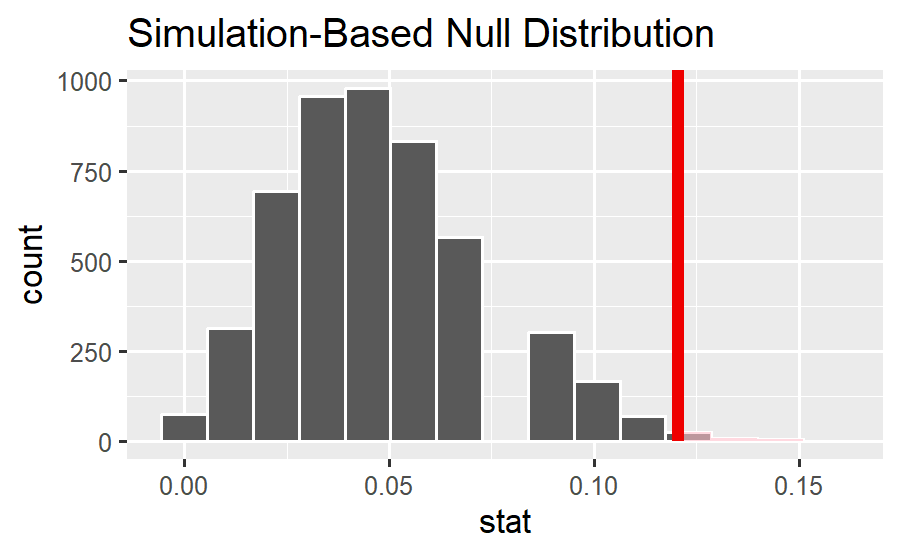

```r
(q4_null_distribution %>%
visualise() +
  shade_p_value(obs_stat = q4_observed_stat,
                direction = "greater")
)
```

```r
q4_null_distribution %>%
  get_pvalue(obs_stat = q4_observed_stat,
                direction = "greater")
```

| p_value |
| --- |
| 0.0086 |

```r
NA
```

# 1.2 Hypothesis testing - Defining the Hypothesis

For the following three business problems write out:

- What kind of test you would use
- H0 and Ha in both mathematical notation and in words.
- Also state the method you would use to generate the null distribution (bootstrap, permutation or draw).

Question 1. You work for a independent coffee shop. The boss tells you that she thinks that around 40% of people in the town (population 30,000 ) know of the coffee shop, but you are skeptical of the estimate and think that the actual percentage is higher. You conduct a random survey of 200 people in the town, asking if respondents are aware of your coffee shop. You want to use the sample to test the hypothesis that more than 40% of the town’s population have heard of the coffee shop.

**Answer 1.**

Test: one sample hypothesis test - proportion (right-sided)

H0: πaware_of_coffee_shop = 0.4 Ha: πaware_of_coffee_shop > 0.4

Null hypothesis: the number of people in the town who are aware of the coffee shop is 40%

Alternative hypothesis: the number of people in the town who are aware of the coffee shop is greater than 40%.

Method to generate null distribution: type = “draw”

**Question 2** You work for a website design company and have performed an A/B test on the position of a banner on a website promoting a particular item.

You selected five days at random last month and then randomly selected 200 of each sampled day’s users into group A and another 200 of that day’s users into group B. Group A continued to be shown the banner at the right hand side of the webpage (its usual position) while group B was shown the banner at the top of the page. You monitored each sampled user’s interactions with the website, in particular the ‘click through rate’ (CTR) on the banner, i.e. what proportion of sampled users clicked on the banner. You want to use the sampled data to test the hypothesis that website users overall are more likely to click on the banner if positioned at the top of the page.

**Answer 2.**

Test: two sample hypothesis test - paired

H0: πCTR(top)−πCTR(right)=0

Ha: πCTR(top)−πCTR(right)>0

H0: the CTR with the banner at the top of the website is the same as (or less than) the CTR with the banner at the right hand side of the website.

Ha: the CTR with the banner at the top of the website is greater than the CTR with the banner at the right hand side of the website.

Method to generate null distribution: type = “permutation”

**Question 3.**

You work as an analyst for a car manufacturing company - they have specific standards they must meet for standards and regulation purposes. You have been asked to check the quality control of the manufacture of a particular car part. You have been given data on a sample of 200 parts produced over the period of a week (the sampled parts were pulled at random from the production line and measured: the factory produced a lot more than 200 parts that week). The specification of the part stipulates a width of 145mm, and the manufacturing process is said to have ‘drifted’ if the mean width of parts differs significantly from 145mm. You want to use the sampled measurements to test whether the process overall has drifted.

**Answer 3.**

Test: one sample hypothesis test - mean

H0: μaverage_width = 145 Ha: μaverage_width ≠ 145

Null hypothesis: the mean car part measurement is equal to the specification width of 145mm

Alternative hypothesis: the mean car part measurement is not equal to the specification width of 145mm

Method to generate null distribution: type = “bootstrap”

# 1.3 Hypothesis Testing - Interpreting the results

For the 3 business problems stated above, imagine we performed you got the following p-values (with the given significance levels) write out your interpretation of the results.

**Question 1.**

Coffee shop problem: Significance level: 0.05, calculated p-value: 0.07

**Answer 1**

The p-value is 7% which is greater than our significance level of 5%. This means that we cannot reject our null hypothesis in favour of our alternative hypothesis, i.e. we cannot say with confidence that more than 40% of the population of the town are aware of the coffee shop.

**Question 2.**

Website company problem. Significance level: 0.01, p-value: 0.006

**Answer 2**

The p-value is 0.6% which is lower than our significance level of 1%. This means that we can reject our null hypothesis and say with confidence that the proportion of website users who click on the banner when at the top right of the page is greater than the proportion of users who click on the banner if it is at the right hand side of the page.

**Question 3.**

Manufacturing company problem. Significance level: 0.05, p-value: 0.55

**Answer 3**